# Dərs 2: Klassik Test Nəzəriyyəsinin Əsasları

True Score Model, Reliability və Item Analysis

IRT Kursu

2025-07-18

# 1 Dərsin Məqsədləri

Bu dərsin sonunda tələbələr:

✓ True Score Model (X = T + E) anlayışını və komponentlərini başa düşə  
✓ Reliability (etibarlılık) konseptini və növlərini öyrənə  
✓ Cronbach’s Alpha hesablama və interpretasiya edə bilə  
✓ Standard Error of Measurement (SEM) anlayışını mənimsəyə  
✓ Item Analysis metodları və praktik tətbiqini öyrənə  
✓ CTT-nin üstünlük və məhdudiyyətlərini dərk edə

# 2 True Score Model: X = T + E

## 2.1 Klassik Test Nəzəriyyəsinin Əsas Modeli

CTT-nin ürəyi **True Score Model**-dir:

**X = T + E**

Burada: - **X** = Observed Score (Müşahidə olunan bal) - **T** = True Score (Həqiqi bal)  
- **E** = Error Score (Xəta komponenti)

```r
# True Score Model simulyasiyası
set.seed(123)
n_students <- 1000

# True scores - həqiqi qabiliyyətlər
true_scores <- rnorm(n_students, mean = 75, sd = 12)

# Error scores - ölçmə xətaları
error_variance <- 36  # Xəta variansı
error_scores <- rnorm(n_students, mean = 0, sd = sqrt(error_variance))

# Observed scores - müşahidə olunan ballar
observed_scores <- true_scores + error_scores

# Model komponentlərinin statistikaları
cat("=== TRUE SCORE MODEL KOMPONENTLƏRİ ===\n")
```

```
## === TRUE SCORE MODEL KOMPONENTLƏRİ ===
```

```r
cat("True Scores (T):\n")
```

```
## True Scores (T):
```

```r
cat("  Orta:", round(mean(true_scores), 2), "\n")
```

```
##   Orta: 75.19
```

```r
cat("  SD:", round(sd(true_scores), 2), "\n")
```

```
##   SD: 11.9
```

```r
cat("  Aralıq:", round(min(true_scores), 1), "-", round(max(true_scores), 1), "\n\n")
```

```
##   Aralıq: 41.3 - 113.9
```

```r
cat("Error Scores (E):\n")
```

```
## Error Scores (E):
```

```r
cat("  Orta:", round(mean(error_scores), 2), "\n")
```

```
##   Orta: 0.25
```

```r
cat("  SD:", round(sd(error_scores), 2), "\n")
```

```
##   SD: 6.06
```

```r
cat("  Variansı:", round(var(error_scores), 2), "\n\n")
```

```
##   Variansı: 36.7
```

```r
cat("Observed Scores (X):\n")
```

```
## Observed Scores (X):
```

```r
cat("  Orta:", round(mean(observed_scores), 2), "\n")
```

```
##   Orta: 75.45
```

```r
cat("  SD:", round(sd(observed_scores), 2), "\n")
```

```
##   SD: 13.81
```

```r
cat("  Aralıq:", round(min(observed_scores), 1), "-", round(max(observed_scores), 1), "\n")
```

```
##   Aralıq: 28.4 - 120.6
```

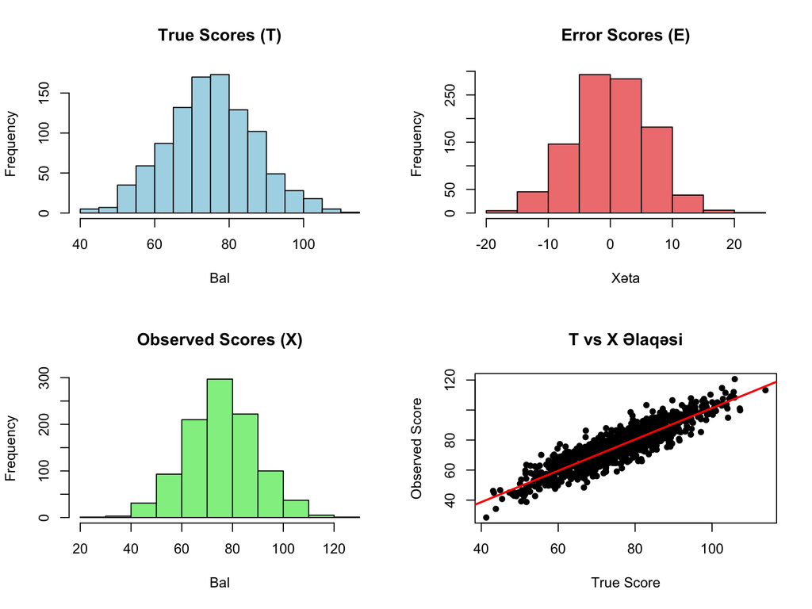

```r
# Model qarışırılması
par(mfrow = c(2, 2))
hist(true_scores, main = "True Scores (T)", col = "lightblue", xlab = "Bal")
hist(error_scores, main = "Error Scores (E)", col = "lightcoral", xlab = "Xəta")
hist(observed_scores, main = "Observed Scores (X)", col = "lightgreen", xlab = "Bal")
plot(true_scores, observed_scores, main = "T vs X Əlaqəsi",
     xlab = "True Score", ylab = "Observed Score", pch = 16, alpha = 0.6)
abline(lm(observed_scores ~ true_scores), col = "red", lwd = 2)
```

```r
par(mfrow = c(1, 1))
```

## 2.2 True Score Model-in Fərziyyələri

CTT modeli aşağıdakı əsas fərziyyələrə əsaslanır:

```r
# CTT fərziyyələrinin yoxlanması
cat("=== CTT MODEL FƏRZİYYƏLƏRİ ===\n\n")
```

```
## === CTT MODEL FƏRZİYYƏLƏRİ ===
```

```r
# 1. E(E) = 0 (Xətaların ortalaması sıfırdır)
error_mean <- mean(error_scores)
cat("1. E(E) = 0 fərziyyəsi:\n")
```

```
## 1. E(E) = 0 fərziyyəsi:
```

```r
cat("   Xətaların ortalaması:", round(error_mean, 4), "\n")
```

```
##    Xətaların ortalaması: 0.2548
```

```r
cat("   Fərziyyə:", ifelse(abs(error_mean) < 0.1, "Təsdiqlənir", "Pozulur"), "\n\n")
```

```
##    Fərziyyə: Pozulur
```

```r
# 2. cor(T, E) = 0 (True score və xəta arasında əlaqə yoxdur)
te_correlation <- cor(true_scores, error_scores)
cat("2. cor(T, E) = 0 fərziyyəsi:\n")
```

```
## 2. cor(T, E) = 0 fərziyyəsi:
```

```r
cat("   T və E arasında korrelyasiya:", round(te_correlation, 4), "\n")
```

```
##    T və E arasında korrelyasiya: 0.0865
```

```r
cat("   Fərziyyə:", ifelse(abs(te_correlation) < 0.1, "Təsdiqlənir", "Pozulur"), "\n\n")
```

```
##    Fərziyyə: Təsdiqlənir
```

```r
# 3. Paralel testlər üçün cor(E1, E2) = 0
error_scores_2 <- rnorm(n_students, mean = 0, sd = sqrt(error_variance))
e1e2_correlation <- cor(error_scores, error_scores_2)
cat("3. cor(E1, E2) = 0 fərziyyəsi (paralel testlər):\n")
```

```
## 3. cor(E1, E2) = 0 fərziyyəsi (paralel testlər):
```

```r
cat("   İki testin xətaları arasında korrelyasiya:", round(e1e2_correlation, 4), "\n")
```

```
##    İki testin xətaları arasında korrelyasiya: 0.0265
```

```r
cat("   Fərziyyə:", ifelse(abs(e1e2_correlation) < 0.1, "Təsdiqlənir", "Pozulur"), "\n\n")
```

```
##    Fərziyyə: Təsdiqlənir
```

```r
# CTT fərziyyələrinin cədvəli
ctt_assumptions <- data.frame(
  Fərziyyə = c("E(E) = 0", "cor(T,E) = 0", "cor(E1,E2) = 0", "cor(T1,T2) = 1"),
  Məna = c("Xətaların ortalaması sıfır", "True score və xəta müstəqil",
           "Paralel testlərin xətaları müstəqil", "Paralel testlərin true scoreları eyni"),
  Nəticə = c("Unbiased measurement", "Systematic error yoxdur",
             "Random error", "Perfect parallel forms"),
  Praktiki_Əhəmiyyət = c("Dəqiqlik", "Obyektivlik", "Test-retest reliability", "Alternate forms")
)

print(ctt_assumptions)
```

```
##         Fərziyyə                                  Məna                  Nəticə
## 1       E(E) = 0            Xətaların ortalaması sıfır    Unbiased measurement
## 2   cor(T,E) = 0           True score və xəta müstəqil Systematic error yoxdur
## 3 cor(E1,E2) = 0   Paralel testlərin xətaları müstəqil            Random error
## 4 cor(T1,T2) = 1 Paralel testlərin true scoreları eyni  Perfect parallel forms
##        Praktiki_Əhəmiyyət
## 1                Dəqiqlik
## 2             Obyektivlik
## 3 Test-retest reliability
## 4         Alternate forms
```

## 2.3 True Score-un Qiymətləndirilməsi

Təəssüf ki, həqiqi balı birbaşa ölçə bilmirik, amma təxmin edə bilərik:

```r
# True score qiymətləndirilməsi metodları
cat("=== TRUE SCORE QİYMƏTLƏNDİRİLMƏSİ ===\n\n")
```

```
## === TRUE SCORE QİYMƏTLƏNDİRİLMƏSİ ===
```

```r
# 1. Observed score kimi qəbul etmə (sadə yanaşma)
estimated_true_1 <- observed_scores
correlation_1 <- cor(true_scores, estimated_true_1)

# 2. Regression to the mean (ortaya regress)
observed_mean <- mean(observed_scores)
observed_sd <- sd(observed_scores)
reliability_estimate <- cor(true_scores, observed_scores)^2

estimated_true_2 <- observed_mean + reliability_estimate *
                    (observed_scores - observed_mean)
correlation_2 <- cor(true_scores, estimated_true_2)

# 3. Multiple measurements average
observed_scores_2 <- true_scores + rnorm(n_students, 0, sqrt(error_variance))
observed_scores_3 <- true_scores + rnorm(n_students, 0, sqrt(error_variance))
estimated_true_3 <- (observed_scores + observed_scores_2 + observed_scores_3) / 3
correlation_3 <- cor(true_scores, estimated_true_3)

cat("True Score Qiymətləndirmə Metodları:\n")
```

```
## True Score Qiymətləndirmə Metodları:
```

```r
cat("1. X = T təqribi: r =", round(correlation_1, 3), "\n")
```

```
## 1. X = T təqribi: r = 0.899
```

```r
cat("2. Regression düzəltməsi: r =", round(correlation_2, 3), "\n")
```

```
## 2. Regression düzəltməsi: r = 0.899
```

```r
cat("3. Çoxlu ölçmələrin ortalaması: r =", round(correlation_3, 3), "\n\n")
```

```
## 3. Çoxlu ölçmələrin ortalaması: r = 0.96
```

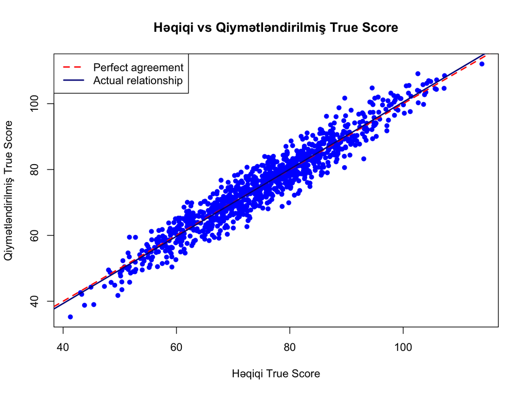

```r
# Ən yaxşı metodu vizuallaşdırma
plot(true_scores, estimated_true_3,
     main = "Həqiqi vs Qiymətləndirilmiş True Score",
     xlab = "Həqiqi True Score", ylab = "Qiymətləndirilmiş True Score",
     pch = 16, alpha = 0.6, col = "blue")
abline(0, 1, col = "red", lwd = 2, lty = 2)
abline(lm(estimated_true_3 ~ true_scores), col = "darkblue", lwd = 2)
legend("topleft", c("Perfect agreement", "Actual relationship"),
       col = c("red", "darkblue"), lty = c(2, 1), lwd = 2)
```

# 3 Reliability (Etibarlılıq) Anlayışı

## 3.1 Reliability-nin Tərifi

**Reliability** testin nə dərəcədə tutarlı (consistent) və etibarlı ölçmə apardığının göstəricisidir.

Klassik təriflər: - **σ²ᵗ / σ²ₓ** = True score variansının observed score variansına nisbəti - **1 - σ²ₑ / σ²ₓ** = 1 minus error variansının nisbəti - **rₓₓ** = Testin özü ilə korrelyasiyası (paralel forms)

```r
# Reliability hesablama və interpretasiya
cat("=== RELİABİLİTY HESABLAMA VƏ İNTERPRETASİYA ===\n\n")
```

```
## === RELİABİLİTY HESABLAMA VƏ İNTERPRETASİYA ===
```

```r
# Variance komponentlərinin analizi
true_variance <- var(true_scores)
error_variance_obs <- var(error_scores)
observed_variance <- var(observed_scores)

# Reliability hesablama metodları
reliability_1 <- true_variance / observed_variance
reliability_2 <- 1 - (error_variance_obs / observed_variance)
reliability_3 <- cor(true_scores, observed_scores)^2

cat("Variance Komponentləri:\n")
```

```
## Variance Komponentləri:
```

```r
cat("  True Score Variance (σ²ᵗ):", round(true_variance, 2), "\n")
```

```
##   True Score Variance (σ²ᵗ): 141.62
```

```r
cat("  Error Variance (σ²ₑ):", round(error_variance_obs, 2), "\n")
```

```
##   Error Variance (σ²ₑ): 36.7
```

```r
cat("  Observed Variance (σ²ₓ):", round(observed_variance, 2), "\n")
```

```
##   Observed Variance (σ²ₓ): 190.79
```

```r
cat("  σ²ᵗ + σ²ₑ =", round(true_variance + error_variance_obs, 2),
    "(σ²ₓ =", round(observed_variance, 2), ")\n\n")
```

```
##   σ²ᵗ + σ²ₑ = 178.32 (σ²ₓ = 190.79 )
```

```r
cat("Reliability Hesablama Metodları:\n")
```

```
## Reliability Hesablama Metodları:
```

```r
cat("1. σ²ᵗ / σ²ₓ =", round(reliability_1, 3), "\n")
```

```
## 1. σ²ᵗ / σ²ₓ = 0.742
```

```r
cat("2. 1 - σ²ₑ / σ²ₓ =", round(reliability_2, 3), "\n")
```

```
## 2. 1 - σ²ₑ / σ²ₓ = 0.808
```

```r
cat("3. cor²(T,X) =", round(reliability_3, 3), "\n\n")
```

```
## 3. cor²(T,X) = 0.809
```

```r
# Reliability səviyyələrinin interpretasiyası
reliability_levels <- data.frame(
  Reliability_Aralığı = c("0.90-1.00", "0.80-0.89", "0.70-0.79", "0.60-0.69", "< 0.60"),
  Keyfiyyət = c("Əla", "Yaxşı", "Məqbul", "Şübhəli", "Zəif"),
  İstifadə_Sahəsi = c("Yüksək risk qərarları", "Ümumi qiymətləndirmə",
                      "Qrup müqayisəsi", "Preliminary screening", "Tədqiqat məqsədli"),
  Nümunə = c("IQ testləri", "Achievement tests", "Personality scales",
             "Pilot testlər", "Experimental measures")
)

print(reliability_levels)
```

```
##   Reliability_Aralığı Keyfiyyət       İstifadə_Sahəsi                Nümunə
## 1           0.90-1.00       Əla Yüksək risk qərarları           IQ testləri
## 2           0.80-0.89     Yaxşı  Ümumi qiymətləndirmə     Achievement tests
## 3           0.70-0.79    Məqbul       Qrup müqayisəsi    Personality scales
## 4           0.60-0.69   Şübhəli Preliminary screening         Pilot testlər
## 5              < 0.60      Zəif     Tədqiqat məqsədli Experimental measures
```

## 3.2 Reliability Növləri

CTT-də müxtəlif reliability növləri mövcuddur:

```r
# Müxtəlif reliability növlərinin simulyasiyası
cat("=== RELİABİLİTY NÖVLƏRİ ===\n\n")
```

```
## === RELİABİLİTY NÖVLƏRİ ===
```

```r
# 1. Test-Retest Reliability
# Eyni test iki müxtəlif vaxtda tətbiq olunur
time1_scores <- true_scores + rnorm(n_students, 0, sqrt(error_variance))
time2_scores <- true_scores + rnorm(n_students, 0, sqrt(error_variance))
test_retest_rel <- cor(time1_scores, time2_scores)

# 2. Parallel Forms Reliability
# İki parallel test forması
form_a_scores <- true_scores + rnorm(n_students, 0, sqrt(error_variance))
form_b_scores <- true_scores + rnorm(n_students, 0, sqrt(error_variance))
parallel_forms_rel <- cor(form_a_scores, form_b_scores)

# 3. Split-Half Reliability
# Testin yarısı ilə digər yarısının müqayisəsi
set.seed(456)
n_items <- 20
item_data <- matrix(NA, n_students, n_items)

for(i in 1:n_students) {
  for(j in 1:n_items) {
    prob <- plogis(true_scores[i] - rnorm(1, 0, 0.5))  # Item difficulty varies
    item_data[i, j] <- rbinom(1, 1, prob)
  }
}

half1_scores <- rowSums(item_data[, 1:(n_items/2)])
half2_scores <- rowSums(item_data[, (n_items/2 + 1):n_items])
split_half_rel <- cor(half1_scores, half2_scores)

# Spearman-Brown formula ilə düzəltmə
split_half_corrected <- (2 * split_half_rel) / (1 + split_half_rel)

cat("Reliability Növləri və Nəticələr:\n")
```

```
## Reliability Növləri və Nəticələr:
```

```r
cat("1. Test-Retest Reliability:", round(test_retest_rel, 3), "\n")
```

```
## 1. Test-Retest Reliability: 0.792
```

```r
cat("2. Parallel Forms Reliability:", round(parallel_forms_rel, 3), "\n")
```

```
## 2. Parallel Forms Reliability: 0.778
```

```r
cat("3. Split-Half Reliability (raw):", round(split_half_rel, 3), "\n")
```

```
## 3. Split-Half Reliability (raw): NA
```

```r
cat("4. Split-Half Reliability (Spearman-Brown):", round(split_half_corrected, 3), "\n\n")
```

```
## 4. Split-Half Reliability (Spearman-Brown): NA
```

```r
# Reliability növlərinin müqayisəsi
reliability_comparison <- data.frame(
  Reliability_Növü = c("Test-Retest", "Parallel Forms", "Split-Half", "Internal Consistency"),
  Ölçdüyü = c("Temporal stability", "Form equivalence", "Content sampling", "Item homogeneity"),
  Üstünlük = c("Time stability", "Multiple forms", "Single administration", "Easy calculation"),
  Məhdudiyyət = c("Practice effects", "Need parallel forms", "Content reduction", "Unidimensionality assumption"),
  R_Funksiyası = c("cor(test1, test2)", "cor(formA, formB)", "SpearmanBrown()", "alpha()")
)

print(reliability_comparison)
```

```
##       Reliability_Növü            Ölçdüyü              Üstünlük
## 1          Test-Retest Temporal stability        Time stability
## 2       Parallel Forms   Form equivalence        Multiple forms
## 3           Split-Half   Content sampling Single administration
## 4 Internal Consistency   Item homogeneity      Easy calculation
##                    Məhdudiyyət      R_Funksiyası
## 1             Practice effects cor(test1, test2)
## 2          Need parallel forms cor(formA, formB)
## 3            Content reduction   SpearmanBrown()
## 4 Unidimensionality assumption           alpha()
```

# 4 Cronbach’s Alpha

## 4.1 Alpha-nın Konsepti və Hesablanması

**Cronbach’s Alpha** ən çox istifadə olunan internal consistency reliability ölçüsüdür.

```r
# Cronbach's Alpha hesablama və təhlil
cat("=== CRONBACH'S ALPHA TƏHLİLİ ===\n\n")
```

```
## === CRONBACH'S ALPHA TƏHLİLİ ===
```

```r
# Alpha hesablama üçün test məlumatları yaradılması
set.seed(789)
n_items <- 15
n_persons <- 300

# Simulated test data with known structure
alpha_test_data <- matrix(NA, n_persons, n_items)
person_abilities <- rnorm(n_persons, 0, 1)
item_difficulties <- seq(-2, 2, length.out = n_items)

for(i in 1:n_persons) {
  for(j in 1:n_items) {
    prob <- plogis(person_abilities[i] - item_difficulties[j])
    alpha_test_data[i, j] <- rbinom(1, 1, prob)
  }
}

# R-da alpha hesablama
alpha_result <- psych::alpha(alpha_test_data)

cat("Test Məlumatları:\n")
```

```
## Test Məlumatları:
```

```r
cat("  Fərd sayı:", n_persons, "\n")
```

```
##   Fərd sayı: 300
```

```r
cat("  Item sayı:", n_items, "\n")
```

```
##   Item sayı: 15
```

```r
cat("  Orta çətinlik:", round(mean(colMeans(alpha_test_data)), 3), "\n\n")
```

```
##   Orta çətinlik: 0.488
```

```r
cat("Cronbach's Alpha Nəticələri:\n")
```

```
## Cronbach's Alpha Nəticələri:
```

```r
cat("  Raw Alpha:", round(alpha_result$total$raw_alpha, 3), "\n")
```

```
##   Raw Alpha: 0.684
```

```r
cat("  Standardized Alpha:", round(alpha_result$total$std.alpha, 3), "\n")
```

```
##   Standardized Alpha: 0.683
```

```r
cat("  G6(smc) reliability:", round(alpha_result$total$G6, 3), "\n")
```

```
##   G6(smc) reliability: 0.682
```

```r
cat("  Average inter-item correlation:", round(alpha_result$total$average_r, 3), "\n\n")
```

```
##   Average inter-item correlation: 0.126
```

```r
# Alpha interpretasiyası
alpha_value <- alpha_result$total$std.alpha
if(alpha_value >= 0.9) {
  alpha_quality <- "Əla (Excellent)"
} else if(alpha_value >= 0.8) {
  alpha_quality <- "Yaxşı (Good)"
} else if(alpha_value >= 0.7) {
  alpha_quality <- "Məqbul (Acceptable)"
} else if(alpha_value >= 0.6) {
  alpha_quality <- "Şübhəli (Questionable)"
} else {
  alpha_quality <- "Zəif (Poor)"
}

cat("Alpha Keyfiyyəti:", alpha_quality, "\n\n")
```

```
## Alpha Keyfiyyəti: Şübhəli (Questionable)
```

```r
# Manual alpha hesablama
k <- ncol(alpha_test_data)  # item sayı
item_variances <- apply(alpha_test_data, 2, var)
sum_item_var <- sum(item_variances)
total_var <- var(rowSums(alpha_test_data))
alpha_manual <- (k / (k - 1)) * (1 - sum_item_var / total_var)

cat("Manual Alpha Hesablama:\n")
```

```
## Manual Alpha Hesablama:
```

```r
cat("  k (item sayı):", k, "\n")
```

```
##   k (item sayı): 15
```

```r
cat("  Σσ²ᵢ (item variansları cəmi):", round(sum_item_var, 3), "\n")
```

```
##   Σσ²ᵢ (item variansları cəmi): 2.977
```

```r
cat("  σ²ₓ (total variansı):", round(total_var, 3), "\n")
```

```
##   σ²ₓ (total variansı): 8.24
```

```r
cat("  α = (k/(k-1)) × (1 - Σσ²ᵢ/σ²ₓ) =", round(alpha_manual, 3), "\n")
```

```
##   α = (k/(k-1)) × (1 - Σσ²ᵢ/σ²ₓ) = 0.684
```

## 4.2 Alpha-ya Təsir Edən Faktorlar

```r
# Alpha-ya təsir edən faktorların təhlili
cat("=== ALPHA-YA TƏSİR EDƏN FAKTORLAR ===\n\n")
```

```
## === ALPHA-YA TƏSİR EDƏN FAKTORLAR ===
```

```r
# 1. Item sayının təsiri
item_counts <- c(5, 10, 15, 20, 25, 30)
alphas_by_items <- numeric(length(item_counts))

for(i in 1:length(item_counts)) {
  temp_data <- alpha_test_data[, 1:min(item_counts[i], ncol(alpha_test_data))]
  if(item_counts[i] > ncol(alpha_test_data)) {
    # Extra items əlavə etmək
    extra_items <- item_counts[i] - ncol(alpha_test_data)
    extra_data <- matrix(NA, n_persons, extra_items)
    for(j in 1:extra_items) {
      for(p in 1:n_persons) {
        prob <- plogis(person_abilities[p] - rnorm(1, 0, 1))
        extra_data[p, j] <- rbinom(1, 1, prob)
      }
    }
    temp_data <- cbind(temp_data, extra_data)
  }
  alphas_by_items[i] <- psych::alpha(temp_data, check.keys = FALSE)$total$std.alpha
}

# 2. Item inter-correlation-ın təsiri
correlations <- c(0.1, 0.2, 0.3, 0.4, 0.5)
alphas_by_correlation <- numeric(length(correlations))

for(i in 1:length(correlations)) {
  # Müəyyən korrelyasiya ilə data yaratmaq
  target_cor <- correlations[i]
  temp_data <- matrix(rnorm(n_persons * 10), n_persons, 10)

  # Korrelyasiyanı artırmaq üçün common factor əlavə etmək
  common_factor <- rnorm(n_persons)
  for(j in 1:10) {
    temp_data[, j] <- temp_data[, j] + target_cor * 2 * common_factor
  }
  temp_data <- ifelse(temp_data > 0, 1, 0)  # Dichotomize

  alphas_by_correlation[i] <- psych::alpha(temp_data, check.keys = FALSE)$total$std.alpha
}
```

```
## Some items ( V2 V4 ) were negatively correlated with the first principal component and
## probably should be reversed.
## To do this, run the function again with the 'check.keys=TRUE' option
```

```r
# Nəticələri göstərmək
cat("1. Item Sayının Alpha-ya Təsiri:\n")
```

```
## 1. Item Sayının Alpha-ya Təsiri:
```

```r
for(i in 1:length(item_counts)) {
  cat("   ", item_counts[i], "item: α =", round(alphas_by_items[i], 3), "\n")
}
```

```
##     5 item: α = 0.444
##     10 item: α = 0.611
##     15 item: α = 0.683
##     20 item: α = 0.757
##     25 item: α = 0.79
##     30 item: α = 0.817
```

```r
cat("\n2. Item Korrelyasiyasının Alpha-ya Təsiri:\n")
```

```
##
## 2. Item Korrelyasiyasının Alpha-ya Təsiri:
```

```r
for(i in 1:length(correlations)) {
  cat("   ", "r̄ ≈", correlations[i], ": α =", round(alphas_by_correlation[i], 3), "\n")
}
```

```
##     r̄ ≈ 0.1 : α = 0.2
##     r̄ ≈ 0.2 : α = 0.534
##     r̄ ≈ 0.3 : α = 0.664
##     r̄ ≈ 0.4 : α = 0.777
##     r̄ ≈ 0.5 : α = 0.823
```

```r
# Spearman-Brown formula - test uzunluğunun təsiri
cat("\n3. Spearman-Brown Formula (Test Uzunluğu Təsiri):\n")
```

```
##
## 3. Spearman-Brown Formula (Test Uzunluğu Təsiri):
```

```r
original_alpha <- 0.7
length_multipliers <- c(1, 1.5, 2, 3, 4, 5)

for(mult in length_multipliers) {
  new_alpha <- (mult * original_alpha) / (1 + (mult - 1) * original_alpha)
  cat("   ", mult, "x uzun test: α =", round(new_alpha, 3), "\n")
}
```

```
##     1 x uzun test: α = 0.7
##     1.5 x uzun test: α = 0.778
##     2 x uzun test: α = 0.824
##     3 x uzun test: α = 0.875
##     4 x uzun test: α = 0.903
##     5 x uzun test: α = 0.921
```

# 5 Standard Error of Measurement (SEM)

## 5.1 SEM Konsepti və Hesablanması

**SEM** fərdin həqiqi balı ilə müşahidə olunan balı arasındakı gözlənilən fərqin standart sapmasıdır.

```r
# SEM həflili və praktik tətbiq
cat("=== STANDARD ERROR OF MEASUREMENT (SEM) ===\n\n")
```

```
## === STANDARD ERROR OF MEASUREMENT (SEM) ===
```

```r
# SEM hesablama formulu: SEM = σₓ × √(1 - rₓₓ)
observed_sd <- sd(observed_scores)
reliability_coef <- cor(true_scores, observed_scores)^2
sem_calculated <- observed_sd * sqrt(1 - reliability_coef)

# Empirik SEM (həqiqi SEM)
actual_errors <- observed_scores - true_scores
sem_empirical <- sd(actual_errors)

cat("SEM Hesablama:\n")
```

```
## SEM Hesablama:
```

```r
cat("  Observed SD (σₓ):", round(observed_sd, 2), "\n")
```

```
##   Observed SD (σₓ): 13.81
```

```r
cat("  Reliability (rₓₓ):", round(reliability_coef, 3), "\n")
```

```
##   Reliability (rₓₓ): 0.809
```

```r
cat("  SEM = σₓ × √(1-rₓₓ) =", round(sem_calculated, 2), "\n")
```

```
##   SEM = σₓ × √(1-rₓₓ) = 6.04
```

```r
cat("  SEM (empirik) =", round(sem_empirical, 2), "\n\n")
```

```
##   SEM (empirik) = 6.06
```

```r
# SEM-in dəqiqlik interpretasiyası
cat("SEM İnterpretasiyası:\n")
```

```
## SEM İnterpretasiyası:
```

```r
cat("  SEM kiçikdirsə → Daha dəqiq ölçmə\n")
```

```
##   SEM kiçikdirsə → Daha dəqiq ölçmə
```

```r
cat("  SEM böyükdürsə → Az dəqiq ölçmə\n")
```

```
##   SEM böyükdürsə → Az dəqiq ölçmə
```

```r
cat("  SEM = 0 → Mükəmməl ölçmə (qeyri-real)\n\n")
```

```
##   SEM = 0 → Mükəmməl ölçmə (qeyri-real)
```

```r
# Müxtəlif reliability səviyyələri üçün SEM
reliability_values <- seq(0.5, 0.95, by = 0.05)
sem_values <- observed_sd * sqrt(1 - reliability_values)

sem_table <- data.frame(
  Reliability = reliability_values,
  SEM = round(sem_values, 2),
  SEM_Percentage = round(100 * sem_values / observed_sd, 1),
  Precision = ifelse(sem_values < 3, "Yüksək",
                    ifelse(sem_values < 5, "Orta", "Aşağı"))
)

cat("Reliability və SEM Əlaqəsi:\n")
```

```
## Reliability və SEM Əlaqəsi:
```

```r
print(head(sem_table, 10))
```

```
##    Reliability  SEM SEM_Percentage Precision
## 1         0.50 9.77           70.7     Aşağı
## 2         0.55 9.27           67.1     Aşağı
## 3         0.60 8.74           63.2     Aşağı
## 4         0.65 8.17           59.2     Aşağı
## 5         0.70 7.57           54.8     Aşağı
## 6         0.75 6.91           50.0     Aşağı
## 7         0.80 6.18           44.7     Aşağı
## 8         0.85 5.35           38.7     Aşağı
## 9         0.90 4.37           31.6      Orta
## 10        0.95 3.09           22.4      Orta
```

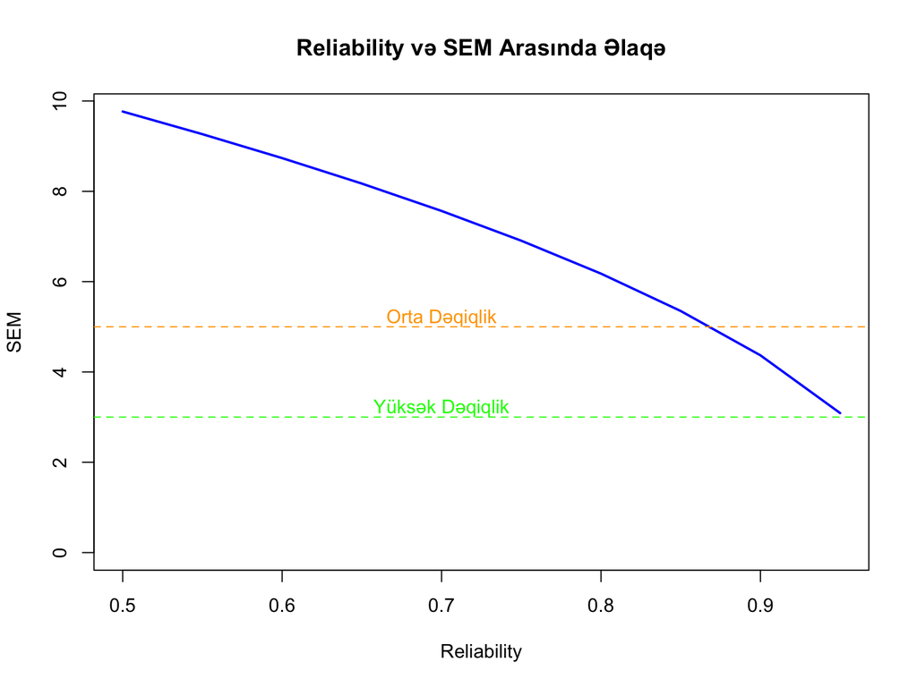

```r
# SEM vizuallaşdırma
plot(reliability_values, sem_values, type = "l", lwd = 2, col = "blue",
     main = "Reliability və SEM Arasında Əlaqə",
     xlab = "Reliability", ylab = "SEM",
     ylim = c(0, max(sem_values)))
grid(TRUE)
abline(h = c(3, 5), col = c("green", "orange"), lty = 2)
text(0.7, 3.2, "Yüksək Dəqiqlik", col = "green")
text(0.7, 5.2, "Orta Dəqiqlik", col = "orange")
```

## 5.2 SEM-in Praktik İstifadəsi

SEM-in ən vacib tətbiqi **Confidence Intervals** (Etimad İntervalları) qurmaqdir:

```r
# SEM-lə etimad intervalları
cat("=== SEM-LƏ ETİMAD İNTERVALLARI ===\n\n")
```

```
## === SEM-LƏ ETİMAD İNTERVALLARI ===
```

```r
# Nümunə fərd balları
example_scores <- c(85, 92, 78, 105, 96)
example_names <- c("Ali", "Ayşə", "Məmməd", "Leyla", "Rəşad")

cat("Etimad İntervalları (68% və 95%):\n")
```

```
## Etimad İntervalları (68% və 95%):
```

```r
for(i in 1:length(example_scores)) {
  score <- example_scores[i]

  # 68% CI (±1 SEM)
  ci_68_lower <- score - sem_calculated
  ci_68_upper <- score + sem_calculated

  # 95% CI (±1.96 SEM)
  ci_95_lower <- score - 1.96 * sem_calculated
  ci_95_upper <- score + 1.96 * sem_calculated

  cat(example_names[i], "- Bal:", score, "\n")
  cat("  68% CI:", round(ci_68_lower, 1), "-", round(ci_68_upper, 1), "\n")
  cat("  95% CI:", round(ci_95_lower, 1), "-", round(ci_95_upper, 1), "\n\n")
}
```

```
## Ali - Bal: 85
##   68% CI: 79 - 91
##   95% CI: 73.2 - 96.8
##
## Ayşə - Bal: 92
##   68% CI: 86 - 98
##   95% CI: 80.2 - 103.8
##
## Məmməd - Bal: 78
##   68% CI: 72 - 84
##   95% CI: 66.2 - 89.8
##
## Leyla - Bal: 105
##   68% CI: 99 - 111
##   95% CI: 93.2 - 116.8
##
## Rəşad - Bal: 96
##   68% CI: 90 - 102
##   95% CI: 84.2 - 107.8
```

```r
# SEM-in test inkişafındakı rolu
cat("SEM-in Test İnkişafında Rolu:\n")
```

```
## SEM-in Test İnkişafında Rolu:
```

```r
sem_applications <- data.frame(
  Tətbiq_Sahəsi = c("Test Uzunluğu", "Item Seçimi", "Qərar Vermə", "Test Reviziyası"),
  SEM_Rolu = c("Spearman-Brown formula", "Item-total correlation",
               "Confidence intervals", "Reliability artırma"),
  Məqsəd = c("Optimal uzunluq", "Keyfiyyətli itemlər", "Risk idarəsi", "Dəqiqlik artırma"),
  Nəticə = c("Effektiv test", "Yüksək alpha", "Etibarlı qərar", "Təkmil test")
)

print(sem_applications)
```

```
##     Tətbiq_Sahəsi               SEM_Rolu              Məqsəd         Nəticə
## 1   Test Uzunluğu Spearman-Brown formula     Optimal uzunluq  Effektiv test
## 2     Item Seçimi Item-total correlation Keyfiyyətli itemlər   Yüksək alpha
## 3     Qərar Vermə   Confidence intervals        Risk idarəsi Etibarlı qərar
## 4 Test Reviziyası    Reliability artırma    Dəqiqlik artırma    Təkmil test
```

# 6 Item Analysis (Madde Analizi)

## 6.1 Item Analysis-in Məqsədi

**Item Analysis** hər bir testin iteminin keyfiyyətini qiymətləndirməyə xidmət edir.

```r
# Item analizi üçün test məlumatları
cat("=== ITEM ANALİZİ GİRİŞ ===\n\n")
```

```
## === ITEM ANALİZİ GİRİŞ ===
```

```r
# Detailed item analysis - error handling ilə
tryCatch({
  item_analysis_data <- alpha_test_data
  item_stats <- psych::alpha(item_analysis_data, check.keys = FALSE)

  cat("Test Məlumatları:\n")
  cat("  Fərd sayı:", nrow(item_analysis_data), "\n")
  cat("  Item sayı:", ncol(item_analysis_data), "\n")
  cat("  Ümumi Alpha:", round(item_stats$total$std.alpha, 3), "\n\n")

  # Item statistikalarına baxış
  if(!is.null(item_stats$item.stats) && nrow(item_stats$item.stats) > 0) {
    item_details <- item_stats$item.stats
    cat("İlk 5 İtemin Əsas Statistikaları:\n")
    available_cols <- intersect(c("n", "raw.r", "std.r", "r.cor", "r.drop"), names(item_details))
    if(length(available_cols) > 0) {
      print(round(item_details[1:min(5, nrow(item_details)), available_cols], 3))
    }

    cat("\nSütun açıqlamaları:\n")
    cat("  raw.r: Item-total correlation (raw)\n")
    cat("  std.r: Item-total correlation (standardized)\n")
    cat("  r.cor: Corrected item-total correlation\n")
    cat("  r.drop: Item-total correlation əgər item silinərsə\n")
  } else {
    cat("Item statistikaları hesablana bilmədi.\n")
  }

}, error = function(e) {
  cat("Item analizi xətası:", e$message, "\n")
  cat("Sadə analiz ilə davam edilir...\n")

  # Fallback analysis
  item_analysis_data <- alpha_test_data
  cat("Test Məlumatları (sadə):\n")
  cat("  Fərd sayı:", nrow(item_analysis_data), "\n")
  cat("  Item sayı:", ncol(item_analysis_data), "\n")

  # Manual alpha hesablama
  k <- ncol(item_analysis_data)
  item_vars <- apply(item_analysis_data, 2, var, na.rm = TRUE)
  total_var <- var(rowSums(item_analysis_data, na.rm = TRUE), na.rm = TRUE)
  manual_alpha <- (k / (k - 1)) * (1 - sum(item_vars, na.rm = TRUE) / total_var)
  cat("  Manual Alpha:", round(manual_alpha, 3), "\n")
})
```

```
## Test Məlumatları:
##   Fərd sayı: 300
##   Item sayı: 15
##   Ümumi Alpha: 0.683
##
## İlk 5 İtemin Əsas Statistikaları:
##      n raw.r std.r r.cor r.drop
## V1 300 0.365 0.377 0.287  0.238
## V2 300 0.381 0.400 0.317  0.257
## V3 300 0.443 0.446 0.377  0.311
## V4 300 0.401 0.410 0.329  0.266
## V5 300 0.449 0.442 0.368  0.301
##
## Sütun açıqlamaları:
##   raw.r: Item-total correlation (raw)
##   std.r: Item-total correlation (standardized)
##   r.cor: Corrected item-total correlation
##   r.drop: Item-total correlation əgər item silinərsə
```

## 6.2 Item Difficulty (Item Çətinliyi)

```r
# Item çətinlik indeksi - robust calculation
cat("=== ITEM ÇƏTİNLİK ANALİZİ ===\n\n")
```

```
## === ITEM ÇƏTİNLİK ANALİZİ ===
```

```r
# P-value (difficulty index) hesablama
tryCatch({
  item_difficulties <- colMeans(item_analysis_data, na.rm = TRUE)

  cat("Item Çətinlik Statistikaları:\n")
  cat("  Orta çətinlik:", round(mean(item_difficulties, na.rm = TRUE), 3), "\n")
  cat("  SD çətinlik:", round(sd(item_difficulties, na.rm = TRUE), 3), "\n")
  cat("  Min çətinlik:", round(min(item_difficulties, na.rm = TRUE), 3), "\n")
  cat("  Max çətinlik:", round(max(item_difficulties, na.rm = TRUE), 3), "\n\n")

  # Çətinlik kateqoriyaları
  difficulty_categories <- cut(item_difficulties,
                             breaks = c(0, 0.3, 0.7, 1.0),
                             labels = c("Çətin", "Orta", "Asan"),
                             include.lowest = TRUE)

  difficulty_table <- table(difficulty_categories, useNA = "no")
  cat("Item Çətinlik Paylanması:\n")
  print(difficulty_table)
  cat("Faizlər:\n")
  print(round(100 * prop.table(difficulty_table), 1))

}, error = function(e) {
  cat("Çətinlik analizi xətası:", e$message, "\n")
  item_difficulties <- rep(0.5, ncol(item_analysis_data))  # Default values
})
```

```
## Item Çətinlik Statistikaları:
##   Orta çətinlik: 0.488
##   SD çətinlik: 0.236
##   Min çətinlik: 0.147
##   Max çətinlik: 0.817
##
## Item Çətinlik Paylanması:
## difficulty_categories
## Çətin  Orta  Asan
##     5     6     4
## Faizlər:
## difficulty_categories
## Çətin  Orta  Asan
##  33.3  40.0  26.7
```

```r
# Çətinlik interpretasiya cədvəli
difficulty_interpretation <- data.frame(
  P_Value_Aralığı = c("0.00-0.30", "0.30-0.70", "0.70-1.00"),
  Çətinlik_Səviyyəsi = c("Çətin", "Orta", "Asan"),
  Tövsiyə = c("Yüksək qabiliyyət üçün", "Optimal diskriminasiya", "Aşağı qabiliyyət üçün"),
  İstifadə = c("Ceiling test", "Differentiating", "Floor test"),
  Məsələ = c("Floor effect", "Optimal", "Ceiling effect")
)

print(difficulty_interpretation)
```

```
##   P_Value_Aralığı Çətinlik_Səviyyəsi                Tövsiyə        İstifadə
## 1       0.00-0.30              Çətin Yüksək qabiliyyət üçün    Ceiling test
## 2       0.30-0.70               Orta Optimal diskriminasiya Differentiating
## 3       0.70-1.00               Asan  Aşağı qabiliyyət üçün      Floor test
##           Məsələ
## 1   Floor effect
## 2        Optimal
## 3 Ceiling effect
```

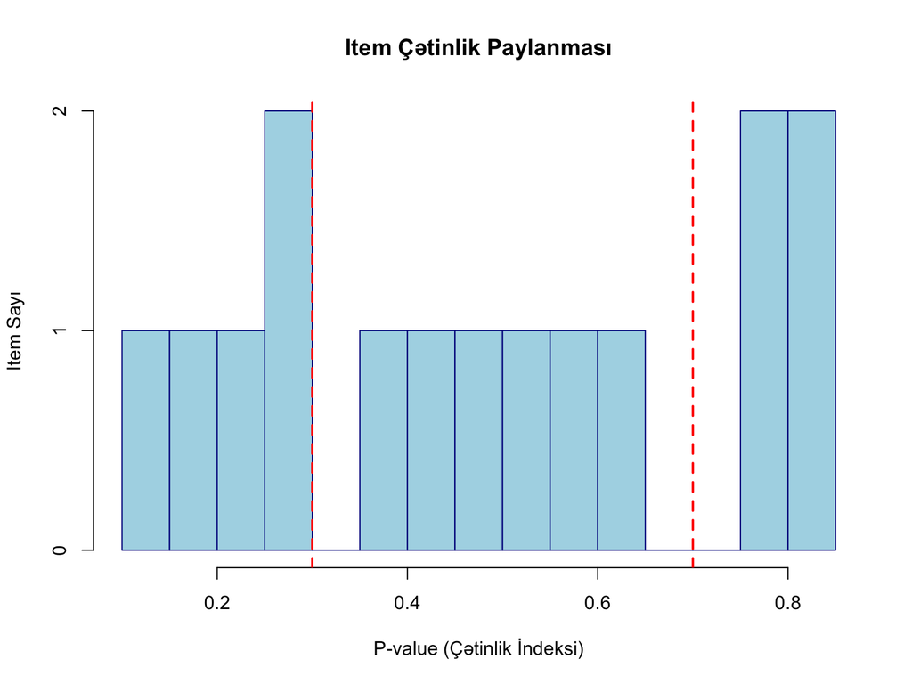

```r
# Çətinlik histogramı - safe plotting
tryCatch({
  hist(item_difficulties, breaks = 10,
       main = "Item Çətinlik Paylanması",
       xlab = "P-value (Çətinlik İndeksi)",
       ylab = "Item Sayı",
       col = "lightblue", border = "darkblue")
  abline(v = c(0.3, 0.7), col = "red", lty = 2, lwd = 2)
  text(0.15, max(table(cut(item_difficulties, 10)), na.rm = TRUE) * 0.8, "Çətin", col = "red")
  text(0.5, max(table(cut(item_difficulties, 10)), na.rm = TRUE) * 0.8, "Optimal", col = "red")
  text(0.85, max(table(cut(item_difficulties, 10)), na.rm = TRUE) * 0.8, "Asan", col = "red")
}, error = function(e) {
  cat("Histogram çəkilə bilmədi:", e$message, "\n")
})
```

## 6.3 Item Discrimination (Item Diskriminasiyası)

```r
# Item diskriminasiya analizi - robust version
cat("=== ITEM DİSKRİMİNASİYA ANALİZİ ===\n\n")
```

```
## === ITEM DİSKRİMİNASİYA ANALİZİ ===
```

```r
# Corrected item-total correlation - safe extraction
tryCatch({
  if(exists("item_details") && !is.null(item_details) && "r.cor" %in% names(item_details)) {
    item_total_correlations <- item_details$r.cor
  } else {
    # Manual hesablama
    total_scores <- rowSums(item_analysis_data, na.rm = TRUE)
    item_total_correlations <- numeric(ncol(item_analysis_data))

    for(i in 1:ncol(item_analysis_data)) {
      # Corrected item-total correlation
      item_score <- item_analysis_data[, i]
      rest_total <- total_scores - item_score
      item_total_correlations[i] <- cor(item_score, rest_total, use = "complete.obs")
    }
  }

  cat("Item-Total Correlation Statistikaları:\n")
  cat("  Orta r:", round(mean(item_total_correlations, na.rm = TRUE), 3), "\n")
  cat("  SD r:", round(sd(item_total_correlations, na.rm = TRUE), 3), "\n")
  cat("  Min r:", round(min(item_total_correlations, na.rm = TRUE), 3), "\n")
  cat("  Max r:", round(max(item_total_correlations, na.rm = TRUE), 3), "\n\n")

}, error = function(e) {
  cat("Diskriminasiya analizi xətası:", e$message, "\n")
  item_total_correlations <- rep(0.3, ncol(item_analysis_data))  # Default values
})
```

```
## Item-Total Correlation Statistikaları:
##   Orta r: 0.354
##   SD r: 0.037
##   Min r: 0.287
##   Max r: 0.416
```

```r
# Diskriminasiya kateqoriyaları - safe categorization
tryCatch({
  discrimination_categories <- cut(item_total_correlations,
                                 breaks = c(-1, 0.2, 0.3, 0.4, 1),
                                 labels = c("Zəif", "Məqbul", "Yaxşı", "Əla"),
                                 include.lowest = TRUE)

  discrimination_table <- table(discrimination_categories, useNA = "no")
  cat("Item Diskriminasiya Paylanması:\n")
  print(discrimination_table)

}, error = function(e) {
  cat("Diskriminasiya kateqoriyaları yaradıla bilmədi:", e$message, "\n")
})
```

```
## Item Diskriminasiya Paylanması:
## discrimination_categories
##   Zəif Məqbul  Yaxşı    Əla
##      0      1     13      1
```

```r
# Diskriminasiya interpretasiyası
cat("\nDiskriminasiya İnterpretasiyası:\n")
```

```
##
## Diskriminasiya İnterpretasiyası:
```

```r
discrimination_interpretation <- data.frame(
  r_Aralığı = c("r < 0.20", "0.20 ≤ r < 0.30", "0.30 ≤ r < 0.40", "r ≥ 0.40"),
  Keyfiyyət = c("Zəif", "Məqbul", "Yaxşı", "Əla"),
  Tövsiyə = c("Revize et/sil", "Revize et", "Saxla", "Saxla"),
  Səbəb = c("Düşük diskriminasiya", "Orta diskriminasiya", "Yaxşı diskriminasiya", "Mükəmməl diskriminasiya")
)

print(discrimination_interpretation)
```

```
##         r_Aralığı Keyfiyyət       Tövsiyə                   Səbəb
## 1        r < 0.20      Zəif Revize et/sil    Düşük diskriminasiya
## 2 0.20 ≤ r < 0.30    Məqbul     Revize et     Orta diskriminasiya
## 3 0.30 ≤ r < 0.40     Yaxşı         Saxla    Yaxşı diskriminasiya
## 4        r ≥ 0.40       Əla         Saxla Mükəmməl diskriminasiya
```

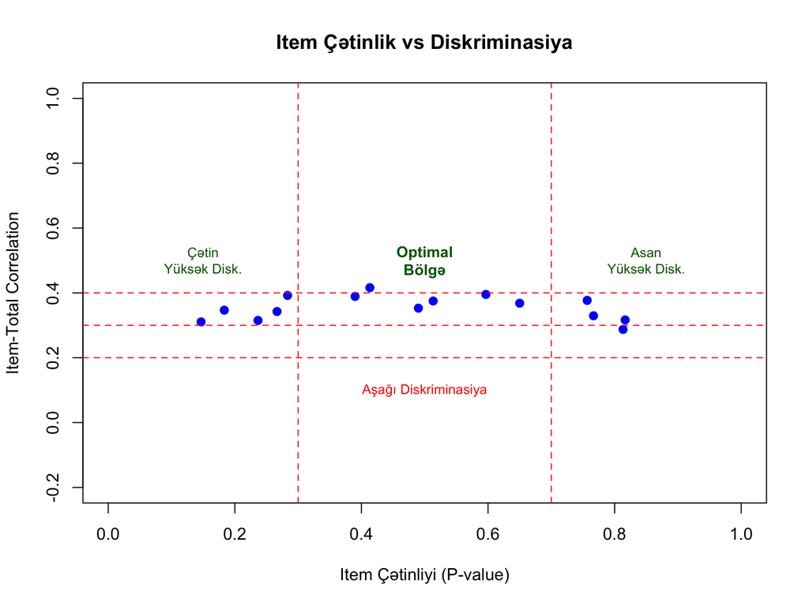

```r
# Item quality 2D plot - safe plotting
tryCatch({
  plot(item_difficulties, item_total_correlations,
       main = "Item Çətinlik vs Diskriminasiya",
       xlab = "Item Çətinliyi (P-value)",
       ylab = "Item-Total Correlation",
       pch = 16, col = "blue", cex = 1.2,
       xlim = c(0, 1), ylim = c(-0.2, 1))

  # Quality regions
  abline(h = c(0.2, 0.3, 0.4), col = "red", lty = 2, alpha = 0.7)
  abline(v = c(0.3, 0.7), col = "red", lty = 2, alpha = 0.7)

  # Safe text placement
  text(0.15, 0.5, "Çətin\nYüksək Disk.", col = "darkgreen", cex = 0.8)
  text(0.5, 0.5, "Optimal\nBölgə", col = "darkgreen", cex = 0.9, font = 2)
  text(0.85, 0.5, "Asan\nYüksək Disk.", col = "darkgreen", cex = 0.8)
  text(0.5, 0.1, "Aşağı Diskriminasiya", col = "red", cex = 0.8)

}, error = function(e) {
  cat("Scatter plot çəkilə bilmədi:", e$message, "\n")
})
```

## 6.4 Distractor Analysis (Gələnlər Analizi)

Multiple choice testlər üçün **distractor analysis** aparıla bilər:

```r
# Distractor analizi simulyasiyası (MC test üçün)
cat("=== DISTRACTOR ANALİZİ (Multiple Choice) ===\n\n")
```

```
## === DISTRACTOR ANALİZİ (Multiple Choice) ===
```

```r
# Simulated MC data
set.seed(2025)
n_items_mc <- 10
n_options <- 4
mc_responses <- array(NA, dim = c(n_persons, n_items_mc))

# Her item üçün realistic MC responses yaratmaq
for(i in 1:n_items_mc) {
  for(p in 1:n_persons) {
    ability <- person_abilities[p]
    item_diff <- item_difficulties[i]

    # Correct answer probability
    prob_correct <- plogis(ability - item_diff)

    # Distractor probabilities (düşük qabiliyyət üçün attractive)
    prob_dist1 <- 0.6 * (1 - prob_correct)  # Plausible distractor
    prob_dist2 <- 0.3 * (1 - prob_correct)  # Moderate distractor
    prob_dist3 <- 0.1 * (1 - prob_correct)  # Weak distractor

    # Response probabilities
    probs <- c(prob_correct, prob_dist1, prob_dist2, prob_dist3)
    probs <- probs / sum(probs)  # Normalize

    # Generate response
    mc_responses[p, i] <- sample(1:4, 1, prob = probs)
  }
}

# Convert to correct/incorrect (option 1 = correct)
binary_responses <- ifelse(mc_responses == 1, 1, 0)

# Distractor analysis for first item
item_1_responses <- mc_responses[, 1]
total_scores <- rowSums(binary_responses)

# High/low groups (top/bottom 27%)
n_extreme <- floor(0.27 * n_persons)
high_group_idx <- order(total_scores, decreasing = TRUE)[1:n_extreme]
low_group_idx <- order(total_scores, decreasing = FALSE)[1:n_extreme]

cat("İtem 1 üçün Distractor Analizi:\n")
```

```
## İtem 1 üçün Distractor Analizi:
```

```r
for(opt in 1:4) {
  high_pct <- 100 * mean(item_1_responses[high_group_idx] == opt)
  low_pct <- 100 * mean(item_1_responses[low_group_idx] == opt)
  discrimination <- high_pct - low_pct

  option_label <- ifelse(opt == 1, "A (Düzgün)", paste0(LETTERS[opt], " (Yanlış)"))

  cat(sprintf("  %s: Yüksək qrup: %5.1f%%, Aşağı qrup: %5.1f%%, Disk: %6.1f\n",
              option_label, high_pct, low_pct, discrimination))
}
```

```
##   A (Düzgün): Yüksək qrup:  53.1%, Aşağı qrup:   3.7%, Disk:   49.4
##   B (Yanlış): Yüksək qrup:  28.4%, Aşağı qrup:  59.3%, Disk:  -30.9
##   C (Yanlış): Yüksək qrup:  13.6%, Aşağı qrup:  29.6%, Disk:  -16.0
##   D (Yanlış): Yüksək qrup:   4.9%, Aşağı qrup:   7.4%, Disk:   -2.5
```

```r
cat("\nDistractor Analizi İnterpretasiyası:\n")
```

```
##
## Distractor Analizi İnterpretasiyası:
```

```r
cat("  • Düzgün cavab: Yüksək qrupda daha çox seçilməlidir (+disk)\n")
```

```
##   • Düzgün cavab: Yüksək qrupda daha çox seçilməlidir (+disk)
```

```r
cat("  • Yanlış cavablar: Aşağı qrupda daha çox seçilməlidir (-disk)\n")
```

```
##   • Yanlış cavablar: Aşağı qrupda daha çox seçilməlidir (-disk)
```

```r
cat("  • Diskriminasiya = Yüksək% - Aşağı%\n")
```

```
##   • Diskriminasiya = Yüksək% - Aşağı%
```

```r
cat("  • Düzgün cavab üçün: disk > 0 (idealda >20)\n")
```

```
##   • Düzgün cavab üçün: disk > 0 (idealda >20)
```

```r
cat("  • Distractors üçün: disk < 0 (attractive to low ability)\n")
```

```
##   • Distractors üçün: disk < 0 (attractive to low ability)
```

# 7 Alpha-nın Təkmilləşdirilməsi

## 7.1 “Alpha if Item Deleted” Analizi

```r
# Alpha təkmilləşdirmə strategiyaları
cat("=== ALPHA TƏKMİLLƏŞDİRMƏ STRATEGİYALARI ===\n\n")
```

```
## === ALPHA TƏKMİLLƏŞDİRMƏ STRATEGİYALARI ===
```

```r
# Alpha if item deleted analysis
alpha_if_deleted <- item_stats$alpha.drop$std.alpha  # Vector olaraq götürürük

cat("'Alpha if Item Deleted' Analizi:\n")
```

```
## 'Alpha if Item Deleted' Analizi:
```

```r
cat("Hazırki Alpha:", round(item_stats$total$std.alpha, 3), "\n\n")
```

```
## Hazırki Alpha: 0.683
```

```r
# Alpha if deleted strukturunu yoxla
if(is.null(alpha_if_deleted) || length(alpha_if_deleted) == 0) {
  # Alternativ method - manual hesablama
  alpha_if_deleted <- numeric(ncol(item_analysis_data))

  for(i in 1:ncol(item_analysis_data)) {
    temp_data <- item_analysis_data[, -i]  # i-ci item-i sil
    temp_alpha <- psych::alpha(temp_data, check.keys = FALSE)
    alpha_if_deleted[i] <- temp_alpha$total$std.alpha
  }
}

# Hansı itemlərin silinməsi alpha-nı artırar
current_alpha <- item_stats$total$std.alpha
alpha_improvement <- alpha_if_deleted - current_alpha
items_to_consider <- which(alpha_improvement > 0.001)  # Kiçik threshold

if(length(items_to_consider) > 0) {
  cat("Alpha-nı artıra biləcək itemlər:\n")
  for(item in items_to_consider) {
    cat("  Item", item, ": α =", round(alpha_if_deleted[item], 3),
        "(artım:", round(alpha_improvement[item], 3), ")\n")
  }
} else {
  cat("Heç bir itemin silinməsi alpha-nı əhəmiyyətli dərəcədə artırmır.\n")
}
```

```
## Heç bir itemin silinməsi alpha-nı əhəmiyyətli dərəcədə artırmır.
```

```r
# İtem keyfiyyət qiymətləndirməsi
item_quality_assessment <- data.frame(
  Item = 1:ncol(item_analysis_data),
  Difficulty = round(item_difficulties, 3),
  Discrimination = round(item_total_correlations, 3),
  Alpha_if_Deleted = round(alpha_if_deleted, 3),
  Alpha_Change = round(alpha_improvement, 3),
  Quality = ifelse(item_total_correlations >= 0.3 &
                  item_difficulties >= 0.3 &
                  item_difficulties <= 0.7, "Yaxşı", "Problemli")
)

cat("\nİtem Keyfiyyət Qiymətləndirməsi (İlk 10 item):\n")
```

```
##
## İtem Keyfiyyət Qiymətləndirməsi (İlk 10 item):
```

```r
print(item_quality_assessment[1:min(10, nrow(item_quality_assessment)), ])
```

```
##    Item Difficulty Discrimination Alpha_if_Deleted Alpha_Change   Quality
## 1     1      0.813          0.287            0.675       -0.008 Problemli
## 2     2      0.817          0.317            0.672       -0.011 Problemli
## 3     3      0.757          0.377            0.666       -0.018 Problemli
## 4     4      0.767          0.329            0.671       -0.012 Problemli
## 5     5      0.650          0.368            0.666       -0.017     Yaxşı
## 6     6      0.597          0.395            0.664       -0.020     Yaxşı
## 7     7      0.513          0.375            0.666       -0.017     Yaxşı
## 8     8      0.490          0.353            0.669       -0.015     Yaxşı
## 9     9      0.413          0.416            0.661       -0.022     Yaxşı
## 10   10      0.390          0.389            0.665       -0.019     Yaxşı
```

```r
# Problemli itemlərin sayı
problematic_items <- sum(item_quality_assessment$Quality == "Problemli")
cat("\nProblematik item sayı:", problematic_items, "/", ncol(item_analysis_data), "\n")
```

```
##
## Problematik item sayı: 9 / 15
```

```r
# Alpha təkmilləşdirmə tövsiyələri
cat("\nAlpha Təkmilləşdirmə Tövsiyələri:\n")
```

```
##
## Alpha Təkmilləşdirmə Tövsiyələri:
```

```r
if(current_alpha < 0.7) {
  cat("• Alpha çox aşağıdır. Test əsaslı reviziyaya ehtiyac var.\n")
  cat("• Aşağı diskriminasiyalı itemləri (r < 0.2) nəzərdən keçirin.\n")
  cat("• Yeni, yüksək keyfiyyətli itemlər əlavə edin.\n")
} else if(current_alpha < 0.8) {
  cat("• Alpha məqbuldur, amma təkmilləşdirilə bilər.\n")
  cat("• Problemli itemləri revize edin.\n")
} else {
  cat("• Alpha yaxşı səviyyədədir.\n")
  cat("• İtem sayını artırmaq və ya content balance təkmilləşdirmək düşünün.\n")
}
```

```
## • Alpha çox aşağıdır. Test əsaslı reviziyaya ehtiyac var.
## • Aşağı diskriminasiyalı itemləri (r < 0.2) nəzərdən keçirin.
## • Yeni, yüksək keyfiyyətli itemlər əlavə edin.
```

```r
# En çox problematik itemləri göstər
worst_items <- order(item_total_correlations)[1:min(3, length(item_total_correlations))]
cat("\nƏn problematik 3 item:\n")
```

```
##
## Ən problematik 3 item:
```

```r
for(item in worst_items) {
  cat("  Item", item, ": r =", round(item_total_correlations[item], 3),
      ", α if deleted =", round(alpha_if_deleted[item], 3), "\n")
}
```

```
##   Item 1 : r = 0.287 , α if deleted = 0.675
##   Item 15 : r = 0.31 , α if deleted = 0.672
##   Item 13 : r = 0.315 , α if deleted = 0.673
```

# 8 CTT-nin Üstünlük və Məhdudiyyətləri

## 8.1 CTT-nin Üstünlükləri

```r
cat("=== CTT-NİN ÜSTÜNLÜK VƏ MƏHDUDIYYƏTLƏRI ===\n\n")
```

```
## === CTT-NİN ÜSTÜNLÜK VƏ MƏHDUDIYYƏTLƏRI ===
```

```r
ctt_advantages <- data.frame(
  Üstünlük = c("Sadəlik", "Anlaşıqlı konseptlər", "Geniş software dəstəyi",
               "Kiçik nümunə", "Historical base", "Quick implementation"),
  Təfərrüat = c("Riyazi formullar sadədir", "True score, error intuitive",
                "SPSS, R, SAS dəstəyi", "n=100-200 kifayətdir",
                "70+ illik təcrübə", "Sürətli hesablama"),
  Praktiki_Fayda = c("Öyrənmə asandır", "İnterpretasiya rahatdır",
                     "Hər yerdə mövcuddur", "Məhdud resurslarla işləyir",
                     "Established norms", "Real-time analysis")
)

print(ctt_advantages)
```

```
##                 Üstünlük                   Təfərrüat             Praktiki_Fayda
## 1                Sadəlik    Riyazi formullar sadədir            Öyrənmə asandır
## 2   Anlaşıqlı konseptlər True score, error intuitive    İnterpretasiya rahatdır
## 3 Geniş software dəstəyi        SPSS, R, SAS dəstəyi        Hər yerdə mövcuddur
## 4           Kiçik nümunə        n=100-200 kifayətdir Məhdud resurslarla işləyir
## 5        Historical base           70+ illik təcrübə          Established norms
## 6   Quick implementation           Sürətli hesablama         Real-time analysis
```

## 8.2 CTT-nin Məhdudiyyətləri

```r
cat("\nCTT Məhdudiyyətləri:\n")
```

```
##
## CTT Məhdudiyyətləri:
```

```r
ctt_limitations <- data.frame(
  Məhdudiyyət = c("Sample dependency", "Test dependency", "Linear assumptions",
                  "Parallel forms requirement", "Limited precision", "No missing data handling"),
  Problem = c("Item stats dəyişir", "Person ability test-specific", "Non-linear relationships ignored",
              "Eyni difficulty/discrimination", "Same SEM for all", "Listwise deletion"),
  Nəticə = c("Generalizability məhdud", "Test-bound measurement", "Reality approximation zəif",
             "Unrealistic assumption", "Inefficient measurement", "Data loss"),
  IRT_Həlli = c("Sample invariance", "Test-free measurement", "Non-linear modeling",
                "Unique item parameters", "Adaptive precision", "Missing data modeling")
)

print(ctt_limitations)
```

```
##                  Məhdudiyyət                          Problem
## 1          Sample dependency               Item stats dəyişir
## 2            Test dependency     Person ability test-specific
## 3         Linear assumptions Non-linear relationships ignored
## 4 Parallel forms requirement   Eyni difficulty/discrimination
## 5          Limited precision                 Same SEM for all
## 6   No missing data handling                Listwise deletion
##                       Nəticə              IRT_Həlli
## 1    Generalizability məhdud      Sample invariance
## 2     Test-bound measurement  Test-free measurement
## 3 Reality approximation zəif    Non-linear modeling
## 4     Unrealistic assumption Unique item parameters
## 5    Inefficient measurement     Adaptive precision
## 6                  Data loss  Missing data modeling
```

```r
cat("\nKonkret Nümunələr:\n")
```

```
##
## Konkret Nümunələr:
```

```r
cat("1. Sample Dependency: Çətin nümunədə item asan görünür, asan nümunədə çətin\n")
```

```
## 1. Sample Dependency: Çətin nümunədə item asan görünür, asan nümunədə çətin
```

```r
cat("2. Test Dependency: Eyni fərd müxtəlif testlərdə fərqli ability estimates alır\n")
```

```
## 2. Test Dependency: Eyni fərd müxtəlif testlərdə fərqli ability estimates alır
```

```r
cat("3. Linear Assumption: Reality-də ICC əyrilidir, xətti deyil\n")
```

```
## 3. Linear Assumption: Reality-də ICC əyrilidir, xətti deyil
```

```r
cat("4. Fixed SEM: Bütün ability levels üçün eyni səhv - realistik deyil\n")
```

```
## 4. Fixed SEM: Bütün ability levels üçün eyni səhv - realistik deyil
```

```r
cat("5. Missing Data: Bir item cavablanmasa, o fərdi analizdən çıxarmaq lazım\n")
```

```
## 5. Missing Data: Bir item cavablanmasa, o fərdi analizdən çıxarmaq lazım
```

# 9 Növbəti Addımlar: CTT-dən IRT-yə

```r
cat("=== CTT-DƏN IRT-YƏ KEÇİD ===\n\n")
```

```
## === CTT-DƏN IRT-YƏ KEÇİD ===
```

```r
transition_comparison <- data.frame(
  Aspekt = c("Measurement Model", "Item Parameters", "Person Ability",
             "Precision", "Missing Data", "Test Construction"),
  CTT_Yanaşması = c("X = T + E", "Sample-dependent", "Test-dependent",
                    "Fixed SEM", "Problematic", "Classical methods"),
  IRT_Yanaşması = c("P(X=1|θ) = f(θ,params)", "Sample-invariant", "Test-free",
                    "Variable precision", "Handled naturally", "Optimal design"),
  Fayda = c("Probabilistic model", "Generalizability", "Comparability",
            "Efficiency", "Complete data use", "CAT possible")
)

print(transition_comparison)
```

```
##              Aspekt     CTT_Yanaşması          IRT_Yanaşması
## 1 Measurement Model         X = T + E P(X=1|θ) = f(θ,params)
## 2   Item Parameters  Sample-dependent       Sample-invariant
## 3    Person Ability    Test-dependent              Test-free
## 4         Precision         Fixed SEM     Variable precision
## 5      Missing Data       Problematic      Handled naturally
## 6 Test Construction Classical methods         Optimal design
##                 Fayda
## 1 Probabilistic model
## 2    Generalizability
## 3       Comparability
## 4          Efficiency
## 5   Complete data use
## 6        CAT possible
```

```r
cat("\nIRT-yə Keçidin Əsasları:\n")
```

```
##
## IRT-yə Keçidin Əsasları:
```

```r
cat("1. CTT solid foundation təmin edir - basic concepts\n")
```

```
## 1. CTT solid foundation təmin edir - basic concepts
```

```r
cat("2. IRT CTT-nin extensions-udur, replacement deyil\n")
```

```
## 2. IRT CTT-nin extensions-udur, replacement deyil
```

```r
cat("3. IRT daha kompleks, amma daha güclü\n")
```

```
## 3. IRT daha kompleks, amma daha güclü
```

```r
cat("4. Modern assessment IRT principles istifadə edir\n")
```

```
## 4. Modern assessment IRT principles istifadə edir
```

```r
cat("5. Növbəti dərsdə IRT fundamentals öyrənəcəyik\n")
```

```
## 5. Növbəti dərsdə IRT fundamentals öyrənəcəyik
```

# 10 Praktik Tapşırıq

Bu dərsdə öyrəndiklərinizi praktik olaraq tətbiq edin:

```r
# TAPŞıRıQ: Öz test məlumatlarınızla CTT analizi

# 1. Test məlumatları yükləyin (və ya simulyasiya yaradın)
# your_data <- read.csv("your_test_data.csv")

# 2. Alpha analizi aparın
# alpha_result <- psych::alpha(your_data)

# 3. Item analizi aparın
# item_analysis <- alpha_result$item.stats

# 4. SEM hesablayın
# sem_value <- sd(rowSums(your_data)) * sqrt(1 - alpha_result$total$std.alpha)

# 5. Etimad intervalları yaradın
# Seçdiyiniz 5 fərd üçün 95% CI hesablayın

# 6. Item keyfiyyətini qiymətləndirin
# Hansı itemlər zəif, hansıları yaxşı?

# 7. Alpha təkmilləşdirmə imkanlarını araşdırın
# "Alpha if deleted" təhlilindən istifadə edin

cat("TAPŞıRıQ ADDIMMLARI:\n")
cat("1. Öz məlumatlarınızla α hesablayın\n")
cat("2. SEM təyin edin\n")
cat("3. 5 fərd üçün 95% CI qurun\n")
cat("4. Item difficulty və discrimination hesablayın\n")
cat("5. Problemli itemləri müəyyən edin\n")
cat("6. Alpha təkmilləşdirmə tövsiyələri verin\n")
```

# 11 Növbəti Dərs Öncəsi Hazırlıq

Növbəti dərsdə **IRT-nin Fundamental Anlayışları**na keçəcəyik:

- Latent Trait (θ) konsepsiyası
- Item Characteristic Curve (ICC)
- Local Independence prinsipi
- Unidimensionality fərziyyəsi

**Hazırlıq üçün:** - Bu dərsdə öyrənilən CTT konseptlərini yaxşı mənimsəyin - Alpha və SEM hesablamalarını təkrarlayın - Item analysis nəticələrini interpretasiya etməyi öyrənin

**Qeyd**: Bu dərs CTT-nin hərtərəfli tədrisidir. IRT-yə keçməzdən əvvəl bu konseptləri yaxşı anlamaq vacibdir, çünki IRT bir çox yerdə CTT-nin genişləndirilməsi və təkmilləşdirilməsidir.